# Final Project

Cameron Kadlubowski

22 May, 2020

# Packages and Data

```r
setwd("~/MATH250")
library(tidyverse)
library(NCStats)
```

```r
hunt <- read.csv("IL_hunting_lic.csv",skip=1) %>%

  rename(year=TXNL_LICN_YEAR,county=COUNTY) %>%

  mutate(county=factor(trimws(county,which="right")),

         License=factor(trimws(License,which="right")))

str(hunt)

head(hunt)



hunt2 <- filterD(hunt,year %in% c("2006","2007","2008","2009","2010","2011"))

str(hunt2)



hunt3 <- filterD(hunt2,county %in% c("COOK","KANE","LAKE","MCHENRY"))

str(hunt3)


theme_CK <- theme_bw() +
    theme(legend.title=element_blank(),
        legend.background=element_rect(fill="khaki"),
        legend.key=element_rect(color="black"),
        legend.key.size=unit(4,"mm"),
        legend.text=element_text(size=8),
        axis.title.x = element_blank(),
        plot.title = element_text(face="bold",size=rel(1.4)),
        plot.subtitle = element_text(size=rel(1.1)),
        plot.background=element_rect(fill="khaki",color="black"),
        axis.title.y=element_text(face="bold",size=12),
        axis.text.y=element_text(size=9))



theme_CK2 <- theme_bw() +
  theme(legend.position="none",
        axis.title.x = element_blank(),
        plot.title = element_text(face="bold",size=rel(1.4)),
        plot.subtitle = element_text(size=rel(1.1)),
        plot.background=element_rect(fill="khaki",color="black"),
        axis.title.y=element_text(face="bold",size=12),
        axis.text.y=element_text(size=9),
        axis.text.x.bottom=element_blank(),
        axis.ticks.x=element_blank())



clrs1 <- c("#999999","#666633","#99FF99","#000000","#E69F00","#56B4E9",
           "#009E73","#F0E442","#0072B2","#D55E00","#CC79A7","#996600",
           "#CC3366")
```

# Total Illinois Hunting License Sales

The following graph comes from a set of data on the sales of Illinois Hunting Licenses provided by illinois.gov. The data were compiled by the Illinois Department of Natural Resources from 2006-2012, with counties and hunting license types as factor variables. In preparation, I filtered the data to narrow the focus from 2006-2011, as the data for 2012 seemed inconsistent. With this graph, I wanted to learn about the overall trends in sales over time in Illinois and how they differed among license types statewide.

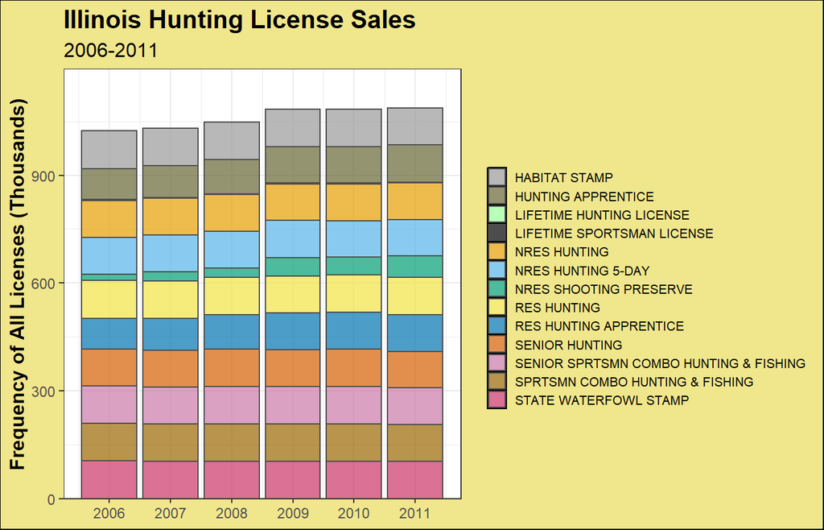

```r
hunt_sum1 <- hunt2 %>%
  group_by(year,License) %>%
  summarize(freq=n()) %>%
  ungroup()
hunt_sum1

p1 <- ggplot(data=hunt_sum1,mapping=aes(x=year,y=freq,fill=License)) +
  geom_bar(stat="identity",color="gray30",alpha=0.7) +
  scale_x_continuous(name="Year",breaks=seq(2006,2011,1)) +
  scale_y_continuous(name="Frequency of All Licenses (Thousands)",
                     expand=expansion(mult=c(0,0.1)),
                     breaks=seq(0,900,300)) +
  scale_fill_manual(values=clrs1) +
    labs(title="Illinois Hunting License Sales",
         subtitle="2006-2011") +
  theme_bw() +
  theme(panel.grid.major.x=element_blank(),
        panel.grid.minor=element_blank()) +
  theme_CK
p1
```